# Risk Factor Analysis

## Outcome Variable

**Outcome Variable:** wast_rec90d

## Predictor Variables

**Intervention Variable:** month

**Adjustment Set:**

unadjusted

## Stratifying Variables

The analysis was stratified on these variable(s):

- agecat
- studyid
- country

## Data Summary

| agecat | studyid | country | month | wast_rec90d | n_cell | n |
| --- | --- | --- | --- | --- | --- | --- |
| 0-24 months | ki0047075b-MAL-ED | BANGLADESH | 1 | 0 | 1 | 124 |
| 0-24 months | ki0047075b-MAL-ED | BANGLADESH | 1 | 1 | 4 | 124 |
| 0-24 months | ki0047075b-MAL-ED | BANGLADESH | 2 | 0 | 6 | 124 |
| 0-24 months | ki0047075b-MAL-ED | BANGLADESH | 2 | 1 | 9 | 124 |
| 0-24 months | ki0047075b-MAL-ED | BANGLADESH | 3 | 0 | 7 | 124 |
| 0-24 months | ki0047075b-MAL-ED | BANGLADESH | 3 | 1 | 17 | 124 |
| 0-24 months | ki0047075b-MAL-ED | BANGLADESH | 4 | 0 | 5 | 124 |
| 0-24 months | ki0047075b-MAL-ED | BANGLADESH | 4 | 1 | 5 | 124 |
| 0-24 months | ki0047075b-MAL-ED | BANGLADESH | 5 | 0 | 6 | 124 |
| 0-24 months | ki0047075b-MAL-ED | BANGLADESH | 5 | 1 | 5 | 124 |
| 0-24 months | ki0047075b-MAL-ED | BANGLADESH | 6 | 0 | 1 | 124 |
| 0-24 months | ki0047075b-MAL-ED | BANGLADESH | 6 | 1 | 2 | 124 |
| 0-24 months | ki0047075b-MAL-ED | BANGLADESH | 7 | 0 | 4 | 124 |
| 0-24 months | ki0047075b-MAL-ED | BANGLADESH | 7 | 1 | 9 | 124 |
| 0-24 months | ki0047075b-MAL-ED | BANGLADESH | 8 | 0 | 1 | 124 |
| 0-24 months | ki0047075b-MAL-ED | BANGLADESH | 8 | 1 | 3 | 124 |
| 0-24 months | ki0047075b-MAL-ED | BANGLADESH | 9 | 0 | 5 | 124 |
| 0-24 months | ki0047075b-MAL-ED | BANGLADESH | 9 | 1 | 16 | 124 |
| 0-24 months | ki0047075b-MAL-ED | BANGLADESH | 10 | 0 | 3 | 124 |
| 0-24 months | ki0047075b-MAL-ED | BANGLADESH | 10 | 1 | 3 | 124 |
| 0-24 months | ki0047075b-MAL-ED | BANGLADESH | 11 | 0 | 2 | 124 |
| 0-24 months | ki0047075b-MAL-ED | BANGLADESH | 11 | 1 | 2 | 124 |
| 0-24 months | ki0047075b-MAL-ED | BANGLADESH | 12 | 0 | 3 | 124 |
| 0-24 months | ki0047075b-MAL-ED | BANGLADESH | 12 | 1 | 5 | 124 |
| 0-24 months | ki0047075b-MAL-ED | BRAZIL | 1 | 0 | 0 | 24 |
| 0-24 months | ki0047075b-MAL-ED | BRAZIL | 1 | 1 | 1 | 24 |
| 0-24 months | ki0047075b-MAL-ED | BRAZIL | 2 | 0 | 1 | 24 |
| 0-24 months | ki0047075b-MAL-ED | BRAZIL | 2 | 1 | 3 | 24 |
| 0-24 months | ki0047075b-MAL-ED | BRAZIL | 3 | 0 | 1 | 24 |
| 0-24 months | ki0047075b-MAL-ED | BRAZIL | 3 | 1 | 0 | 24 |

[output cut: 1818 more lines]

The following strata were considered:

- agecat: 0-24 months, studyid: ki0047075b-MAL-ED, country: BANGLADESH
- agecat: 0-24 months, studyid: ki0047075b-MAL-ED, country: BRAZIL
- agecat: 0-24 months, studyid: ki0047075b-MAL-ED, country: INDIA
- agecat: 0-24 months, studyid: ki0047075b-MAL-ED, country: NEPAL
- agecat: 0-24 months, studyid: ki0047075b-MAL-ED, country: PERU
- agecat: 0-24 months, studyid: ki0047075b-MAL-ED, country: SOUTH AFRICA
- agecat: 0-24 months, studyid: ki0047075b-MAL-ED, country: TANZANIA, UNITED REPUBLIC OF
- agecat: 0-24 months, studyid: ki1000108-CMC-V-BCS-2002, country: INDIA
- agecat: 0-24 months, studyid: ki1000108-IRC, country: INDIA
- agecat: 0-24 months, studyid: ki1000109-EE, country: PAKISTAN
- agecat: 0-24 months, studyid: ki1000109-ResPak, country: PAKISTAN
- agecat: 0-24 months, studyid: ki1000304b-SAS-CompFeed, country: INDIA
- agecat: 0-24 months, studyid: ki1000304b-SAS-FoodSuppl, country: INDIA
- agecat: 0-24 months, studyid: ki1017093-NIH-Birth, country: BANGLADESH
- agecat: 0-24 months, studyid: ki1066203-TanzaniaChild2, country: TANZANIA, UNITED REPUBLIC OF
- agecat: 0-24 months, studyid: ki1101329-Keneba, country: GAMBIA
- agecat: 0-24 months, studyid: ki1112895-Guatemala BSC, country: GUATEMALA
- agecat: 0-24 months, studyid: ki1112895-iLiNS-Zinc, country: BURKINA FASO
- agecat: 0-24 months, studyid: ki1113344-GMS-Nepal, country: NEPAL
- agecat: 0-24 months, studyid: ki1114097-CMIN, country: BANGLADESH
- agecat: 0-24 months, studyid: ki1114097-CONTENT, country: PERU
- agecat: 0-24 months, studyid: ki1119695-PROBIT, country: BELARUS
- agecat: 0-24 months, studyid: ki1126311-ZVITAMBO, country: ZIMBABWE
- agecat: 0-24 months, studyid: ki1148112-LCNI-5, country: MALAWI
- agecat: 0-24 months, studyid: kiGH5241-JiVitA-3, country: BANGLADESH
- agecat: 0-24 months, studyid: kiGH5241-JiVitA-4, country: BANGLADESH
- agecat: 0-6 months, studyid: ki0047075b-MAL-ED, country: BANGLADESH
- agecat: 0-6 months, studyid: ki0047075b-MAL-ED, country: BRAZIL
- agecat: 0-6 months, studyid: ki0047075b-MAL-ED, country: INDIA
- agecat: 0-6 months, studyid: ki0047075b-MAL-ED, country: NEPAL
- agecat: 0-6 months, studyid: ki0047075b-MAL-ED, country: PERU
- agecat: 0-6 months, studyid: ki0047075b-MAL-ED, country: SOUTH AFRICA
- agecat: 0-6 months, studyid: ki0047075b-MAL-ED, country: TANZANIA, UNITED REPUBLIC OF
- agecat: 0-6 months, studyid: ki1000108-CMC-V-BCS-2002, country: INDIA
- agecat: 0-6 months, studyid: ki1000108-IRC, country: INDIA
- agecat: 0-6 months, studyid: ki1000109-EE, country: PAKISTAN
- agecat: 0-6 months, studyid: ki1000109-ResPak, country: PAKISTAN
- agecat: 0-6 months, studyid: ki1000304b-SAS-CompFeed, country: INDIA
- agecat: 0-6 months, studyid: ki1000304b-SAS-FoodSuppl, country: INDIA
- agecat: 0-6 months, studyid: ki1017093-NIH-Birth, country: BANGLADESH
- agecat: 0-6 months, studyid: ki1066203-TanzaniaChild2, country: TANZANIA, UNITED REPUBLIC OF
- agecat: 0-6 months, studyid: ki1101329-Keneba, country: GAMBIA
- agecat: 0-6 months, studyid: ki1112895-Guatemala BSC, country: GUATEMALA
- agecat: 0-6 months, studyid: ki1113344-GMS-Nepal, country: NEPAL
- agecat: 0-6 months, studyid: ki1114097-CMIN, country: BANGLADESH
- agecat: 0-6 months, studyid: ki1114097-CONTENT, country: PERU
- agecat: 0-6 months, studyid: ki1119695-PROBIT, country: BELARUS
- agecat: 0-6 months, studyid: ki1126311-ZVITAMBO, country: ZIMBABWE
- agecat: 0-6 months, studyid: ki1148112-LCNI-5, country: MALAWI
- agecat: 0-6 months, studyid: kiGH5241-JiVitA-3, country: BANGLADESH
- agecat: 0-6 months, studyid: kiGH5241-JiVitA-4, country: BANGLADESH
- agecat: 6-24 months, studyid: ki0047075b-MAL-ED, country: BANGLADESH
- agecat: 6-24 months, studyid: ki0047075b-MAL-ED, country: BRAZIL
- agecat: 6-24 months, studyid: ki0047075b-MAL-ED, country: INDIA
- agecat: 6-24 months, studyid: ki0047075b-MAL-ED, country: NEPAL
- agecat: 6-24 months, studyid: ki0047075b-MAL-ED, country: PERU
- agecat: 6-24 months, studyid: ki0047075b-MAL-ED, country: SOUTH AFRICA
- agecat: 6-24 months, studyid: ki0047075b-MAL-ED, country: TANZANIA, UNITED REPUBLIC OF
- agecat: 6-24 months, studyid: ki1000108-CMC-V-BCS-2002, country: INDIA
- agecat: 6-24 months, studyid: ki1000108-IRC, country: INDIA
- agecat: 6-24 months, studyid: ki1000109-EE, country: PAKISTAN
- agecat: 6-24 months, studyid: ki1000109-ResPak, country: PAKISTAN
- agecat: 6-24 months, studyid: ki1000304b-SAS-CompFeed, country: INDIA
- agecat: 6-24 months, studyid: ki1000304b-SAS-FoodSuppl, country: INDIA
- agecat: 6-24 months, studyid: ki1017093-NIH-Birth, country: BANGLADESH
- agecat: 6-24 months, studyid: ki1066203-TanzaniaChild2, country: TANZANIA, UNITED REPUBLIC OF
- agecat: 6-24 months, studyid: ki1101329-Keneba, country: GAMBIA
- agecat: 6-24 months, studyid: ki1112895-Guatemala BSC, country: GUATEMALA
- agecat: 6-24 months, studyid: ki1112895-iLiNS-Zinc, country: BURKINA FASO
- agecat: 6-24 months, studyid: ki1113344-GMS-Nepal, country: NEPAL
- agecat: 6-24 months, studyid: ki1114097-CMIN, country: BANGLADESH
- agecat: 6-24 months, studyid: ki1114097-CONTENT, country: PERU
- agecat: 6-24 months, studyid: ki1119695-PROBIT, country: BELARUS
- agecat: 6-24 months, studyid: ki1126311-ZVITAMBO, country: ZIMBABWE
- agecat: 6-24 months, studyid: ki1148112-LCNI-5, country: MALAWI
- agecat: 6-24 months, studyid: kiGH5241-JiVitA-3, country: BANGLADESH
- agecat: 6-24 months, studyid: kiGH5241-JiVitA-4, country: BANGLADESH

### Dropped Strata

Some strata were dropped due to rare outcomes:

- agecat: 0-24 months, studyid: ki0047075b-MAL-ED, country: BANGLADESH
- agecat: 0-24 months, studyid: ki0047075b-MAL-ED, country: BRAZIL
- agecat: 0-24 months, studyid: ki0047075b-MAL-ED, country: INDIA
- agecat: 0-24 months, studyid: ki0047075b-MAL-ED, country: NEPAL
- agecat: 0-24 months, studyid: ki0047075b-MAL-ED, country: PERU
- agecat: 0-24 months, studyid: ki0047075b-MAL-ED, country: SOUTH AFRICA
- agecat: 0-24 months, studyid: ki0047075b-MAL-ED, country: TANZANIA, UNITED REPUBLIC OF
- agecat: 0-24 months, studyid: ki1000109-EE, country: PAKISTAN
- agecat: 0-24 months, studyid: ki1000109-ResPak, country: PAKISTAN
- agecat: 0-24 months, studyid: ki1000304b-SAS-FoodSuppl, country: INDIA
- agecat: 0-24 months, studyid: ki1112895-Guatemala BSC, country: GUATEMALA
- agecat: 0-24 months, studyid: ki1112895-iLiNS-Zinc, country: BURKINA FASO
- agecat: 0-24 months, studyid: ki1113344-GMS-Nepal, country: NEPAL
- agecat: 0-24 months, studyid: ki1114097-CMIN, country: BANGLADESH
- agecat: 0-24 months, studyid: ki1114097-CONTENT, country: PERU
- agecat: 0-24 months, studyid: ki1148112-LCNI-5, country: MALAWI
- agecat: 0-24 months, studyid: kiGH5241-JiVitA-4, country: BANGLADESH
- agecat: 0-6 months, studyid: ki0047075b-MAL-ED, country: BANGLADESH
- agecat: 0-6 months, studyid: ki0047075b-MAL-ED, country: BRAZIL
- agecat: 0-6 months, studyid: ki0047075b-MAL-ED, country: INDIA
- agecat: 0-6 months, studyid: ki0047075b-MAL-ED, country: NEPAL
- agecat: 0-6 months, studyid: ki0047075b-MAL-ED, country: PERU
- agecat: 0-6 months, studyid: ki0047075b-MAL-ED, country: SOUTH AFRICA
- agecat: 0-6 months, studyid: ki0047075b-MAL-ED, country: TANZANIA, UNITED REPUBLIC OF
- agecat: 0-6 months, studyid: ki1000108-CMC-V-BCS-2002, country: INDIA
- agecat: 0-6 months, studyid: ki1000108-IRC, country: INDIA
- agecat: 0-6 months, studyid: ki1000109-EE, country: PAKISTAN
- agecat: 0-6 months, studyid: ki1000109-ResPak, country: PAKISTAN
- agecat: 0-6 months, studyid: ki1000304b-SAS-FoodSuppl, country: INDIA
- agecat: 0-6 months, studyid: ki1017093-NIH-Birth, country: BANGLADESH
- agecat: 0-6 months, studyid: ki1066203-TanzaniaChild2, country: TANZANIA, UNITED REPUBLIC OF
- agecat: 0-6 months, studyid: ki1112895-Guatemala BSC, country: GUATEMALA
- agecat: 0-6 months, studyid: ki1113344-GMS-Nepal, country: NEPAL
- agecat: 0-6 months, studyid: ki1114097-CMIN, country: BANGLADESH
- agecat: 0-6 months, studyid: ki1114097-CONTENT, country: PERU
- agecat: 0-6 months, studyid: ki1148112-LCNI-5, country: MALAWI
- agecat: 0-6 months, studyid: kiGH5241-JiVitA-4, country: BANGLADESH
- agecat: 6-24 months, studyid: ki0047075b-MAL-ED, country: BANGLADESH
- agecat: 6-24 months, studyid: ki0047075b-MAL-ED, country: BRAZIL
- agecat: 6-24 months, studyid: ki0047075b-MAL-ED, country: INDIA
- agecat: 6-24 months, studyid: ki0047075b-MAL-ED, country: NEPAL
- agecat: 6-24 months, studyid: ki0047075b-MAL-ED, country: PERU
- agecat: 6-24 months, studyid: ki0047075b-MAL-ED, country: SOUTH AFRICA
- agecat: 6-24 months, studyid: ki0047075b-MAL-ED, country: TANZANIA, UNITED REPUBLIC OF
- agecat: 6-24 months, studyid: ki1000108-CMC-V-BCS-2002, country: INDIA
- agecat: 6-24 months, studyid: ki1000108-IRC, country: INDIA
- agecat: 6-24 months, studyid: ki1000109-EE, country: PAKISTAN
- agecat: 6-24 months, studyid: ki1000109-ResPak, country: PAKISTAN
- agecat: 6-24 months, studyid: ki1000304b-SAS-CompFeed, country: INDIA
- agecat: 6-24 months, studyid: ki1000304b-SAS-FoodSuppl, country: INDIA
- agecat: 6-24 months, studyid: ki1017093-NIH-Birth, country: BANGLADESH
- agecat: 6-24 months, studyid: ki1112895-Guatemala BSC, country: GUATEMALA
- agecat: 6-24 months, studyid: ki1112895-iLiNS-Zinc, country: BURKINA FASO
- agecat: 6-24 months, studyid: ki1113344-GMS-Nepal, country: NEPAL
- agecat: 6-24 months, studyid: ki1114097-CMIN, country: BANGLADESH
- agecat: 6-24 months, studyid: ki1114097-CONTENT, country: PERU
- agecat: 6-24 months, studyid: ki1119695-PROBIT, country: BELARUS
- agecat: 6-24 months, studyid: ki1126311-ZVITAMBO, country: ZIMBABWE
- agecat: 6-24 months, studyid: ki1148112-LCNI-5, country: MALAWI
- agecat: 6-24 months, studyid: kiGH5241-JiVitA-3, country: BANGLADESH
- agecat: 6-24 months, studyid: kiGH5241-JiVitA-4, country: BANGLADESH

## Methods Detail

We’re interested in the causal parameters $E[Y_a]$ for all values of $a \in \mathcal{A}$. These parameters represent the mean outcome if, possibly contrary to fact, we intervened to set all units to have $A=a$. Under the randomization and positivity assumptions, these are identified by the statistical parameters $\psi_a=E_W[E_{Y|A,W}(Y|A=a,W)]$. In addition, we’re interested in the mean of $Y$, $E[Y]$ under no intervention (the observed mean). We will estimate these parameters by using SuperLearner to fit the relevant likelihood factors – $E_{Y|A,W}(Y|A=a,W)$ and $p(A=a|W)$, and then updating our likelihood fit using a joint TMLE.

For unadjusted analyses ($W=\{\}$), initial likelihoods were estimated using Lrnr_glm to estimate the simple $E(Y|A)$ and Lrnr_mean to estimate $p(A)$. For adjusted analyses, a small library containing Lrnr_glmnet, Lrnr_xgboost, and Lrnr_mean was used.

Having estimated these parameters, we will then use the delta method to estimate relative risks and attributable risks relative to a prespecified baseline level of $A$.

# Results Detail

## Results Plots

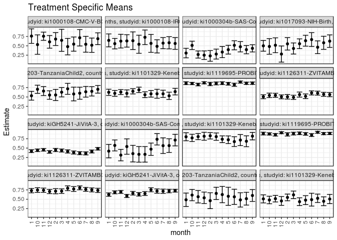

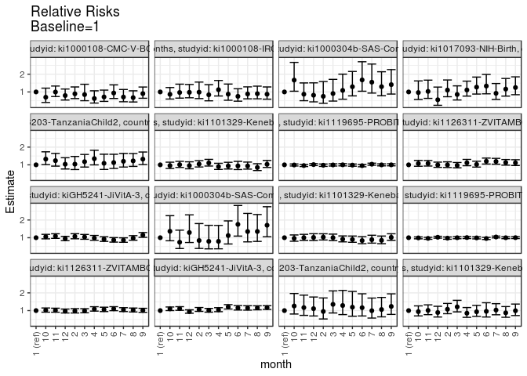

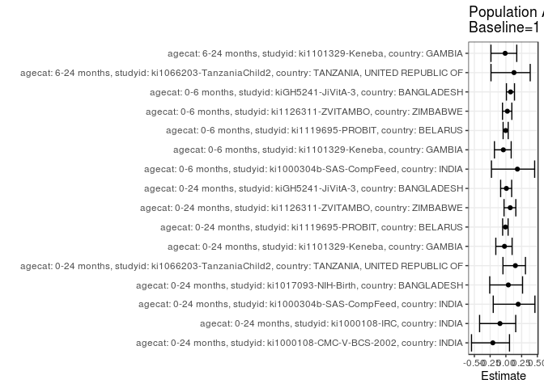

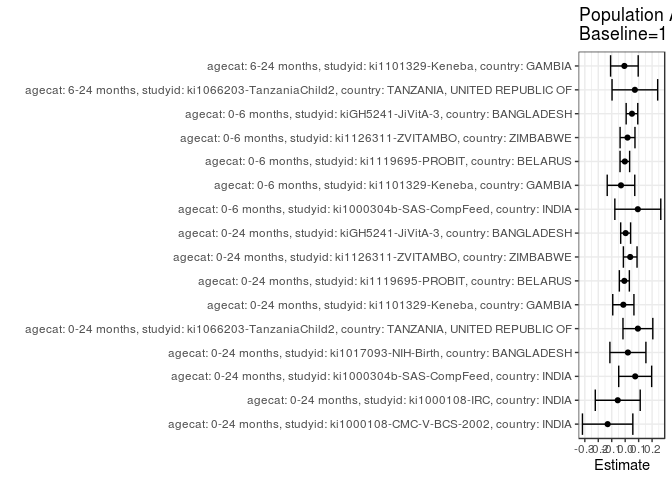

## Results Table

### Parameter: TSM

| agecat | studyid | country | intervention_level | baseline_level | estimate | ci_lower | ci_upper |
| --- | --- | --- | --- | --- | --- | --- | --- |
| 0-24 months | ki1000108-CMC-V-BCS-2002 | INDIA | 1 | NA | 0.7600000 | 0.5660151 | 0.9539849 |
| 0-24 months | ki1000108-CMC-V-BCS-2002 | INDIA | 2 | NA | 0.6800000 | 0.5080091 | 0.8519909 |
| 0-24 months | ki1000108-CMC-V-BCS-2002 | INDIA | 3 | NA | 0.6470588 | 0.3526697 | 0.9414479 |
| 0-24 months | ki1000108-CMC-V-BCS-2002 | INDIA | 4 | NA | 0.4782609 | 0.2586034 | 0.6979183 |
| 0-24 months | ki1000108-CMC-V-BCS-2002 | INDIA | 5 | NA | 0.5454545 | 0.3561138 | 0.7347953 |
| 0-24 months | ki1000108-CMC-V-BCS-2002 | INDIA | 6 | NA | 0.7142857 | 0.4959735 | 0.9325979 |
| 0-24 months | ki1000108-CMC-V-BCS-2002 | INDIA | 7 | NA | 0.5416667 | 0.3294185 | 0.7539148 |
| 0-24 months | ki1000108-CMC-V-BCS-2002 | INDIA | 8 | NA | 0.5161290 | 0.3252597 | 0.7069984 |
| 0-24 months | ki1000108-CMC-V-BCS-2002 | INDIA | 9 | NA | 0.6896552 | 0.5324088 | 0.8469016 |
| 0-24 months | ki1000108-CMC-V-BCS-2002 | INDIA | 10 | NA | 0.5333333 | 0.2739743 | 0.7926924 |
| 0-24 months | ki1000108-CMC-V-BCS-2002 | INDIA | 11 | NA | 0.7560976 | 0.6471570 | 0.8650381 |
| 0-24 months | ki1000108-CMC-V-BCS-2002 | INDIA | 12 | NA | 0.6060606 | 0.4362489 | 0.7758723 |
| 0-24 months | ki1000108-IRC | INDIA | 1 | NA | 0.6451613 | 0.4725102 | 0.8178124 |
| 0-24 months | ki1000108-IRC | INDIA | 2 | NA | 0.6363636 | 0.4006552 | 0.8720720 |
| 0-24 months | ki1000108-IRC | INDIA | 3 | NA | 0.5416667 | 0.3005109 | 0.7828224 |
| 0-24 months | ki1000108-IRC | INDIA | 4 | NA | 0.7272727 | 0.5326364 | 0.9219090 |
| 0-24 months | ki1000108-IRC | INDIA | 5 | NA | 0.5652174 | 0.3263159 | 0.8041189 |
| 0-24 months | ki1000108-IRC | INDIA | 6 | NA | 0.4857143 | 0.3097969 | 0.6616317 |
| 0-24 months | ki1000108-IRC | INDIA | 7 | NA | 0.5714286 | 0.4230264 | 0.7198308 |
| 0-24 months | ki1000108-IRC | INDIA | 8 | NA | 0.5813953 | 0.4190767 | 0.7437140 |
| 0-24 months | ki1000108-IRC | INDIA | 9 | NA | 0.5625000 | 0.4064115 | 0.7185885 |
| 0-24 months | ki1000108-IRC | INDIA | 10 | NA | 0.5581395 | 0.4185154 | 0.6977636 |
| 0-24 months | ki1000108-IRC | INDIA | 11 | NA | 0.6250000 | 0.4423429 | 0.8076571 |
| 0-24 months | ki1000108-IRC | INDIA | 12 | NA | 0.6304348 | 0.4645516 | 0.7963180 |
| 0-24 months | ki1000304b-SAS-CompFeed | INDIA | 1 | NA | 0.3064516 | 0.1791303 | 0.4337729 |
| 0-24 months | ki1000304b-SAS-CompFeed | INDIA | 2 | NA | 0.2307692 | 0.0878681 | 0.3736704 |
| 0-24 months | ki1000304b-SAS-CompFeed | INDIA | 3 | NA | 0.2790698 | 0.1465175 | 0.4116220 |
| 0-24 months | ki1000304b-SAS-CompFeed | INDIA | 4 | NA | 0.3333333 | 0.1840436 | 0.4826231 |
| 0-24 months | ki1000304b-SAS-CompFeed | INDIA | 5 | NA | 0.3968254 | 0.2795968 | 0.5140540 |
| 0-24 months | ki1000304b-SAS-CompFeed | INDIA | 6 | NA | 0.5142857 | 0.3934607 | 0.6351107 |

[output cut: 162 more lines]

### Parameter: E(Y)

| agecat | studyid | country | intervention_level | baseline_level | estimate | ci_lower | ci_upper |
| --- | --- | --- | --- | --- | --- | --- | --- |
| 0-24 months | ki1000108-CMC-V-BCS-2002 | INDIA | NA | NA | 0.6296296 | 0.5734927 | 0.6857666 |
| 0-24 months | ki1000108-IRC | INDIA | NA | NA | 0.5898734 | 0.5376978 | 0.6420491 |
| 0-24 months | ki1000304b-SAS-CompFeed | INDIA | NA | NA | 0.3808354 | 0.3457640 | 0.4159068 |
| 0-24 months | ki1017093-NIH-Birth | BANGLADESH | NA | NA | 0.5201900 | 0.4695846 | 0.5707955 |
| 0-24 months | ki1066203-TanzaniaChild2 | TANZANIA, UNITED REPUBLIC OF | NA | NA | 0.6269285 | 0.5892870 | 0.6645700 |
| 0-24 months | ki1101329-Keneba | GAMBIA | NA | NA | 0.6105033 | 0.5863646 | 0.6346419 |
| 0-24 months | ki1119695-PROBIT | BELARUS | NA | NA | 0.8612051 | 0.8511051 | 0.8713052 |
| 0-24 months | ki1126311-ZVITAMBO | ZIMBABWE | NA | NA | 0.5432918 | 0.5268968 | 0.5596869 |
| 0-24 months | kiGH5241-JiVitA-3 | BANGLADESH | NA | NA | 0.4221371 | 0.4110175 | 0.4332567 |
| 0-6 months | ki1000304b-SAS-CompFeed | INDIA | NA | NA | 0.5131965 | 0.4596632 | 0.5667297 |
| 0-6 months | ki1101329-Keneba | GAMBIA | NA | NA | 0.7720994 | 0.7419223 | 0.8022766 |
| 0-6 months | ki1119695-PROBIT | BELARUS | NA | NA | 0.8855266 | 0.8758983 | 0.8951550 |
| 0-6 months | ki1126311-ZVITAMBO | ZIMBABWE | NA | NA | 0.7475189 | 0.7305656 | 0.7644721 |
| 0-6 months | kiGH5241-JiVitA-3 | BANGLADESH | NA | NA | 0.6751162 | 0.6617750 | 0.6884574 |
| 6-24 months | ki1066203-TanzaniaChild2 | TANZANIA, UNITED REPUBLIC OF | NA | NA | 0.5576408 | 0.5054408 | 0.6098407 |
| 6-24 months | ki1101329-Keneba | GAMBIA | NA | NA | 0.5045290 | 0.4730969 | 0.5359611 |

### Parameter: RR

| agecat | studyid | country | intervention_level | baseline_level | estimate | ci_lower | ci_upper |
| --- | --- | --- | --- | --- | --- | --- | --- |
| 0-24 months | ki1000108-CMC-V-BCS-2002 | INDIA | 1 | 1 | 1.0000000 | 1.0000000 | 1.0000000 |
| 0-24 months | ki1000108-CMC-V-BCS-2002 | INDIA | 2 | 1 | 0.8947368 | 0.6246818 | 1.2815390 |
| 0-24 months | ki1000108-CMC-V-BCS-2002 | INDIA | 3 | 1 | 0.8513932 | 0.5053216 | 1.4344733 |
| 0-24 months | ki1000108-CMC-V-BCS-2002 | INDIA | 4 | 1 | 0.6292906 | 0.3721284 | 1.0641668 |
| 0-24 months | ki1000108-CMC-V-BCS-2002 | INDIA | 5 | 1 | 0.7177033 | 0.4664810 | 1.1042209 |
| 0-24 months | ki1000108-CMC-V-BCS-2002 | INDIA | 6 | 1 | 0.9398496 | 0.6310975 | 1.3996528 |
| 0-24 months | ki1000108-CMC-V-BCS-2002 | INDIA | 7 | 1 | 0.7127193 | 0.4464547 | 1.1377835 |
| 0-24 months | ki1000108-CMC-V-BCS-2002 | INDIA | 8 | 1 | 0.6791171 | 0.4333392 | 1.0642935 |
| 0-24 months | ki1000108-CMC-V-BCS-2002 | INDIA | 9 | 1 | 0.9074410 | 0.6444635 | 1.2777283 |
| 0-24 months | ki1000108-CMC-V-BCS-2002 | INDIA | 10 | 1 | 0.7017544 | 0.4052341 | 1.2152463 |
| 0-24 months | ki1000108-CMC-V-BCS-2002 | INDIA | 11 | 1 | 0.9948652 | 0.7421623 | 1.3336123 |
| 0-24 months | ki1000108-CMC-V-BCS-2002 | INDIA | 12 | 1 | 0.7974482 | 0.5458794 | 1.1649525 |
| 0-24 months | ki1000108-IRC | INDIA | 1 | 1 | 1.0000000 | 1.0000000 | 1.0000000 |
| 0-24 months | ki1000108-IRC | INDIA | 2 | 1 | 0.9863636 | 0.6245718 | 1.5577283 |
| 0-24 months | ki1000108-IRC | INDIA | 3 | 1 | 0.8395833 | 0.4993920 | 1.4115168 |
| 0-24 months | ki1000108-IRC | INDIA | 4 | 1 | 1.1272727 | 0.7721535 | 1.6457140 |
| 0-24 months | ki1000108-IRC | INDIA | 5 | 1 | 0.8760870 | 0.5312591 | 1.4447346 |
| 0-24 months | ki1000108-IRC | INDIA | 6 | 1 | 0.7528571 | 0.4798999 | 1.1810669 |
| 0-24 months | ki1000108-IRC | INDIA | 7 | 1 | 0.8857143 | 0.6099992 | 1.2860505 |
| 0-24 months | ki1000108-IRC | INDIA | 8 | 1 | 0.9011628 | 0.6121260 | 1.3266784 |
| 0-24 months | ki1000108-IRC | INDIA | 9 | 1 | 0.8718750 | 0.5929608 | 1.2819835 |
| 0-24 months | ki1000108-IRC | INDIA | 10 | 1 | 0.8651163 | 0.5998193 | 1.2477527 |
| 0-24 months | ki1000108-IRC | INDIA | 11 | 1 | 0.9687500 | 0.6518089 | 1.4398032 |
| 0-24 months | ki1000108-IRC | INDIA | 12 | 1 | 0.9771739 | 0.6713966 | 1.4222129 |
| 0-24 months | ki1000304b-SAS-CompFeed | INDIA | 1 | 1 | 1.0000000 | 1.0000000 | 1.0000000 |
| 0-24 months | ki1000304b-SAS-CompFeed | INDIA | 2 | 1 | 0.7530364 | 0.3572460 | 1.5873202 |
| 0-24 months | ki1000304b-SAS-CompFeed | INDIA | 3 | 1 | 0.9106487 | 0.4845544 | 1.7114304 |
| 0-24 months | ki1000304b-SAS-CompFeed | INDIA | 4 | 1 | 1.0877193 | 0.5904410 | 2.0038129 |
| 0-24 months | ki1000304b-SAS-CompFeed | INDIA | 5 | 1 | 1.2949039 | 0.7778575 | 2.1556340 |
| 0-24 months | ki1000304b-SAS-CompFeed | INDIA | 6 | 1 | 1.6781955 | 1.0413652 | 2.7044691 |

[output cut: 162 more lines]

### Parameter: PAR

| agecat | studyid | country | intervention_level | baseline_level | estimate | ci_lower | ci_upper |
| --- | --- | --- | --- | --- | --- | --- | --- |
| 0-24 months | ki1000108-CMC-V-BCS-2002 | INDIA | 1 | NA | -0.1303704 | -0.3175966 | 0.0568558 |
| 0-24 months | ki1000108-IRC | INDIA | 1 | NA | -0.0552879 | -0.2222494 | 0.1116737 |
| 0-24 months | ki1000304b-SAS-CompFeed | INDIA | 1 | NA | 0.0743838 | -0.0480880 | 0.1968556 |
| 0-24 months | ki1017093-NIH-Birth | BANGLADESH | 1 | NA | 0.0201900 | -0.1136125 | 0.1539925 |
| 0-24 months | ki1066203-TanzaniaChild2 | TANZANIA, UNITED REPUBLIC OF | 1 | NA | 0.0944609 | -0.0164284 | 0.2053503 |
| 0-24 months | ki1101329-Keneba | GAMBIA | 1 | NA | -0.0137005 | -0.0924335 | 0.0650324 |
| 0-24 months | ki1119695-PROBIT | BELARUS | 1 | NA | -0.0061418 | -0.0433776 | 0.0310940 |
| 0-24 months | ki1126311-ZVITAMBO | ZIMBABWE | 1 | NA | 0.0374095 | -0.0133471 | 0.0881661 |
| 0-24 months | kiGH5241-JiVitA-3 | BANGLADESH | 1 | NA | 0.0034254 | -0.0334475 | 0.0402984 |
| 0-6 months | ki1000304b-SAS-CompFeed | INDIA | 1 | NA | 0.0938416 | -0.0768830 | 0.2645663 |
| 0-6 months | ki1101329-Keneba | GAMBIA | 1 | NA | -0.0311792 | -0.1335148 | 0.0711563 |
| 0-6 months | ki1119695-PROBIT | BELARUS | 1 | NA | -0.0025853 | -0.0382468 | 0.0330763 |
| 0-6 months | ki1126311-ZVITAMBO | ZIMBABWE | 1 | NA | 0.0174304 | -0.0378777 | 0.0727384 |
| 0-6 months | kiGH5241-JiVitA-3 | BANGLADESH | 1 | NA | 0.0504022 | 0.0072724 | 0.0935320 |
| 6-24 months | ki1066203-TanzaniaChild2 | TANZANIA, UNITED REPUBLIC OF | 1 | NA | 0.0719265 | -0.0977237 | 0.2415767 |
| 6-24 months | ki1101329-Keneba | GAMBIA | 1 | NA | -0.0058877 | -0.1084930 | 0.0967176 |

### Parameter: PAF

| agecat | studyid | country | intervention_level | baseline_level | estimate | ci_lower | ci_upper |
| --- | --- | --- | --- | --- | --- | --- | --- |
| 0-24 months | ki1000108-CMC-V-BCS-2002 | INDIA | 1 | NA | -0.2070588 | -0.5456250 | 0.0573451 |
| 0-24 months | ki1000108-IRC | INDIA | 1 | NA | -0.0937284 | -0.4174182 | 0.1560418 |
| 0-24 months | ki1000304b-SAS-CompFeed | INDIA | 1 | NA | 0.1953174 | -0.2007108 | 0.4607243 |
| 0-24 months | ki1017093-NIH-Birth | BANGLADESH | 1 | NA | 0.0388128 | -0.2562172 | 0.2645533 |
| 0-24 months | ki1066203-TanzaniaChild2 | TANZANIA, UNITED REPUBLIC OF | 1 | NA | 0.1506726 | -0.0465071 | 0.3107003 |
| 0-24 months | ki1101329-Keneba | GAMBIA | 1 | NA | -0.0224414 | -0.1598954 | 0.0987236 |
| 0-24 months | ki1119695-PROBIT | BELARUS | 1 | NA | -0.0071316 | -0.0513110 | 0.0351912 |
| 0-24 months | ki1126311-ZVITAMBO | ZIMBABWE | 1 | NA | 0.0688571 | -0.0294339 | 0.1577632 |
| 0-24 months | kiGH5241-JiVitA-3 | BANGLADESH | 1 | NA | 0.0081145 | -0.0831984 | 0.0917298 |
| 0-6 months | ki1000304b-SAS-CompFeed | INDIA | 1 | NA | 0.1828571 | -0.2287268 | 0.4565737 |
| 0-6 months | ki1101329-Keneba | GAMBIA | 1 | NA | -0.0403824 | -0.1817142 | 0.0840462 |
| 0-6 months | ki1119695-PROBIT | BELARUS | 1 | NA | -0.0029195 | -0.0440106 | 0.0365544 |
| 0-6 months | ki1126311-ZVITAMBO | ZIMBABWE | 1 | NA | 0.0233176 | -0.0535574 | 0.0945833 |
| 0-6 months | kiGH5241-JiVitA-3 | BANGLADESH | 1 | NA | 0.0746571 | 0.0084627 | 0.1364324 |
| 6-24 months | ki1066203-TanzaniaChild2 | TANZANIA, UNITED REPUBLIC OF | 1 | NA | 0.1289835 | -0.2360974 | 0.3862379 |
| 6-24 months | ki1101329-Keneba | GAMBIA | 1 | NA | -0.0116697 | -0.2369178 | 0.1725598 |